# Baseball Analytics

Asvin Sritharan

02/03/2020

Preliminary Analyis

We plot data individually to get a feel for the data we are working with

```r
library(tidyverse)
baseball <- read.csv("baseball.csv")
```

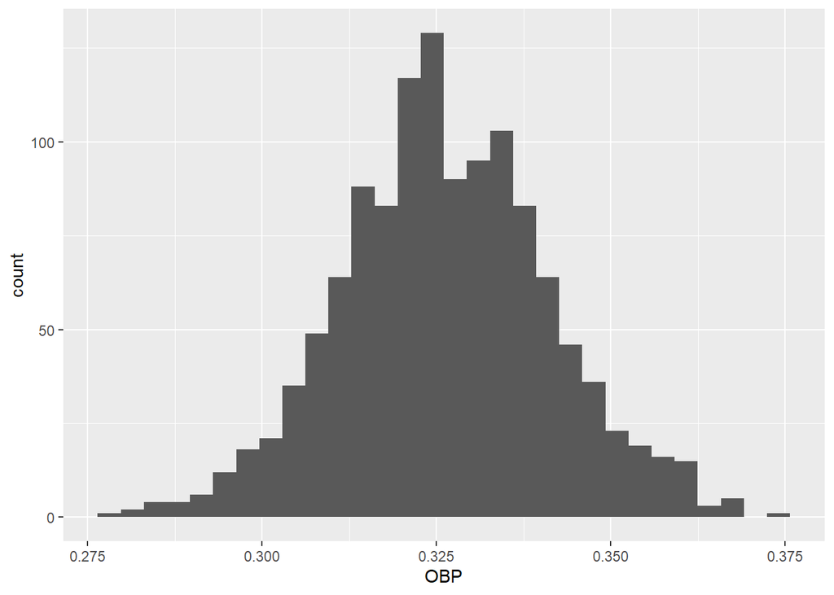

```r
ggplot(baseball, aes(x=OBP)) + geom_histogram()
```

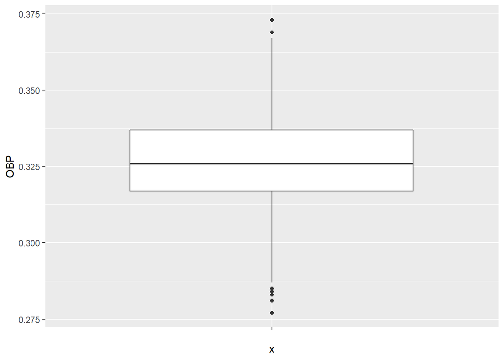

```r
ggplot(baseball, aes(x="", y=OBP)) + geom_boxplot()
```

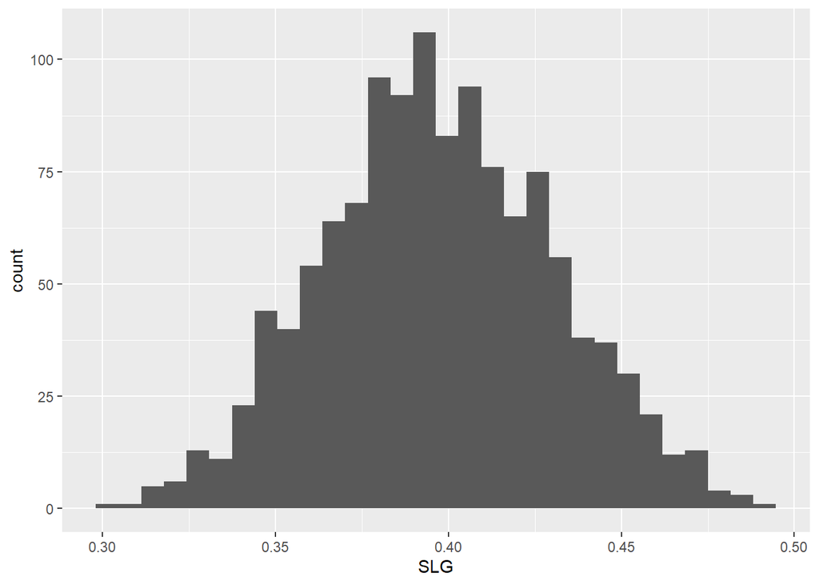

```r
ggplot(baseball, aes(x=SLG)) + geom_histogram()
```

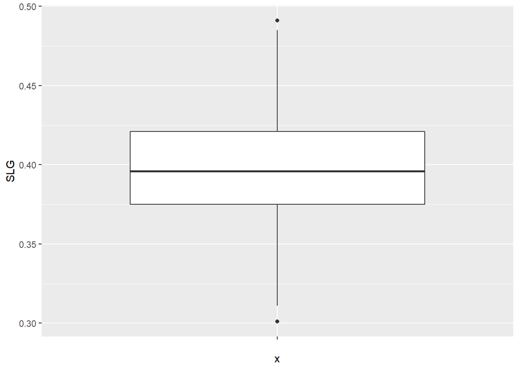

```r
ggplot(baseball, aes(x="", y=SLG)) + geom_boxplot()
```

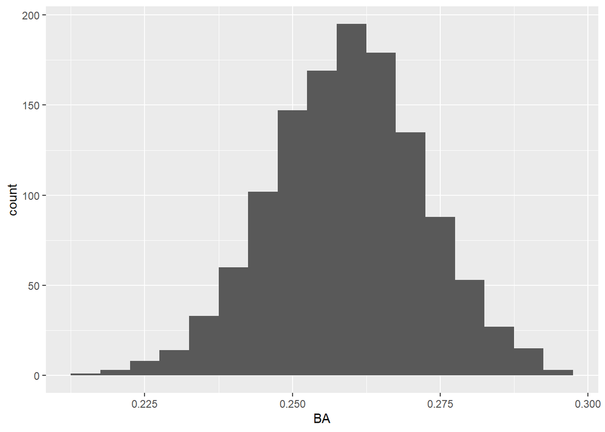

```r
ggplot(baseball, aes(x=BA)) + geom_histogram(bins = 17)
```

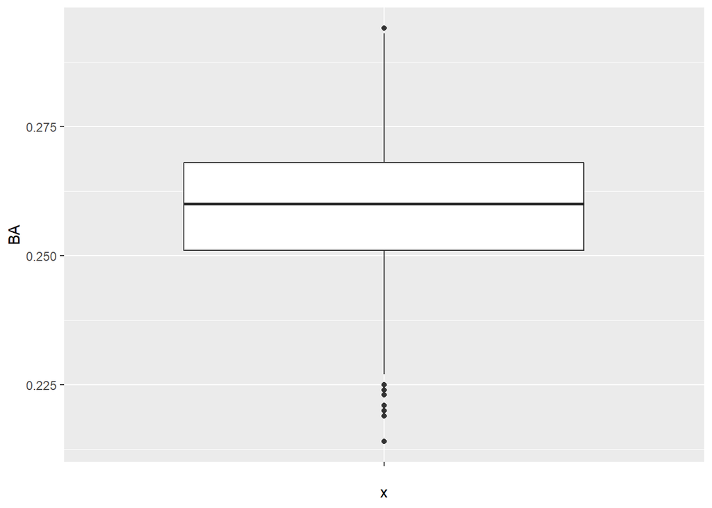

```r
ggplot(baseball, aes(x="", y=BA)) + geom_boxplot()
```

```r
mean(baseball$OBP)
```

```
## [1] 0.3263312
```

```r
median(baseball$OBP)
```

```
## [1] 0.326
```

```r
mean(baseball$SLG)
```

```
## [1] 0.3973417
```

```r
median(baseball$SLG)
```

```
## [1] 0.396
```

```r
mean(baseball$BA)
```

```
## [1] 0.2592727
```

```r
median(baseball$BA)
```

```
## [1] 0.26
```

Marginal Regression Analysis

```r
# create a model for predicting runs scored by creating model on batting average
model <- lm(RS ~ BA, data = baseball)
# get coefficients
coefficients(model)
```

```
## (Intercept)          BA
##    -805.511    5864.840
```

```r
# get r^2
summary(model)$r.squared
```

```
## [1] 0.6839284
```

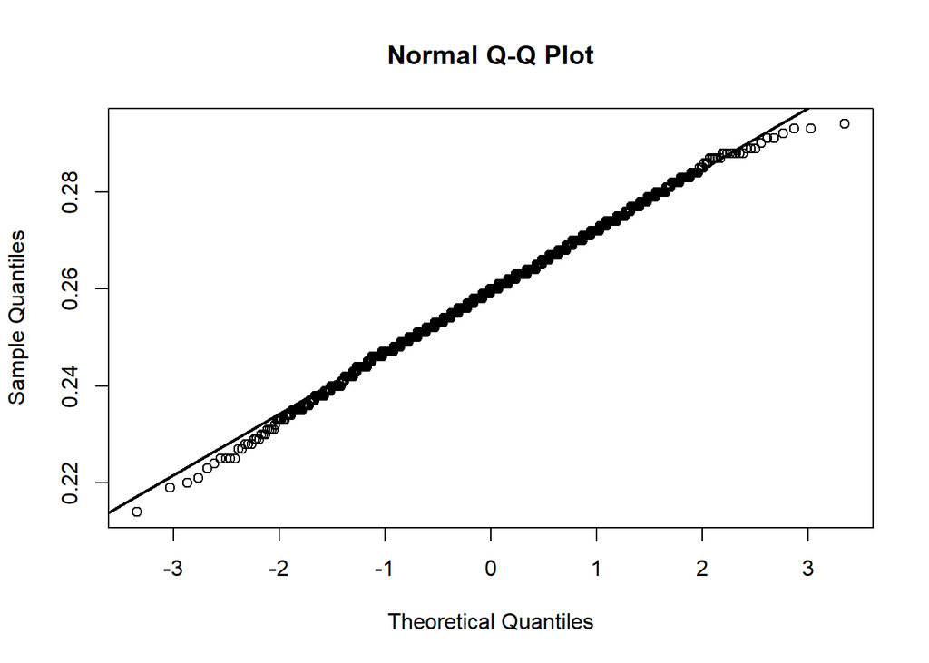

```r
# plot qq plot of batting averate data
qqnorm(baseball$BA)
qqline(baseball$BA, lwd=2)
```

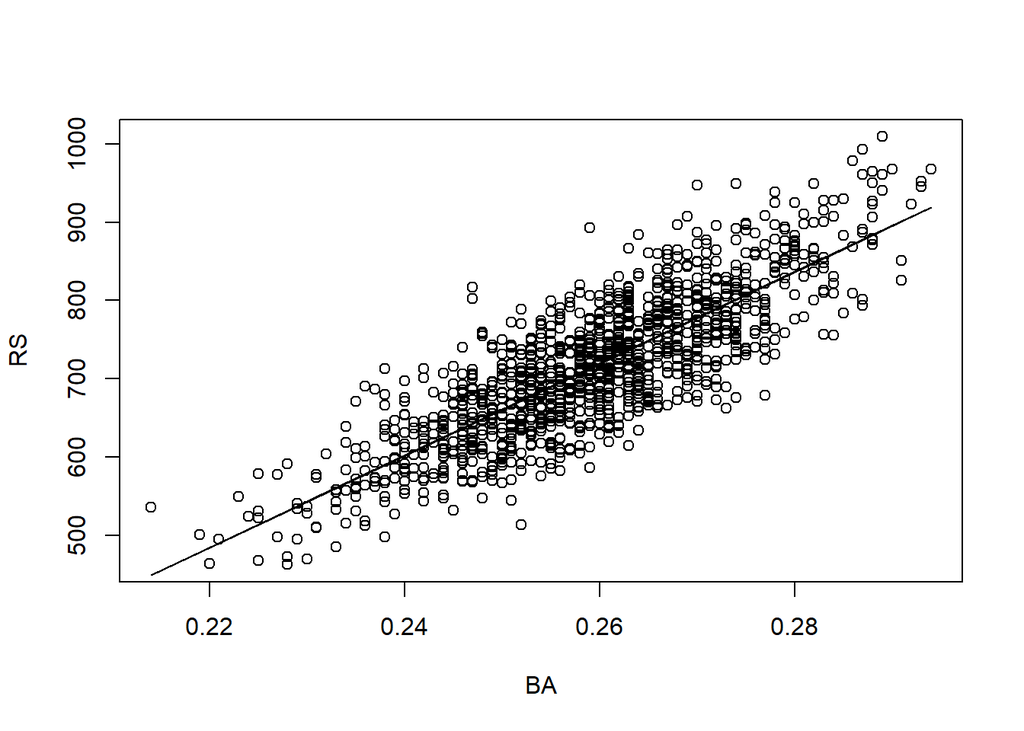

```r
plot(RS~BA, baseball)
lines(baseball$BA, predict(model))
```

The QQPlot shows that the data is not skewed as it follows the line very closely and it has a very light tail

```r
# create linear regression model for predicting runs scored using on-base percentage
model <- lm(RS ~ OBP, data = baseball)
# coefficients of the model
coefficients(model)
```

```
## (Intercept)         OBP
##   -1076.602    5490.386
```

```r
# get the r squared value
summary(model)$r.squared
```

```
## [1] 0.8108862
```

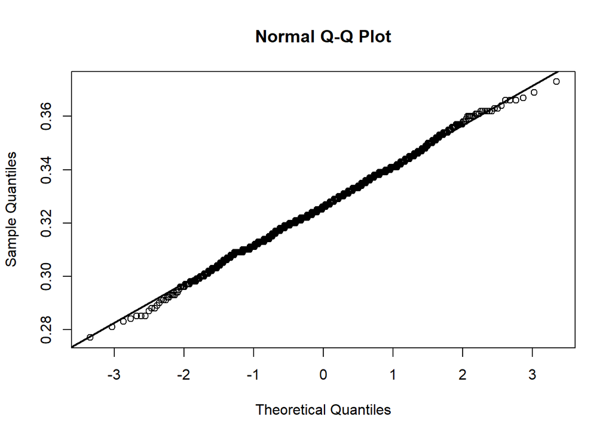

```r
#plot qqnorm and qq line onto data
qqnorm(baseball$OBP)
qqline(baseball$OBP, lwd=2)
```

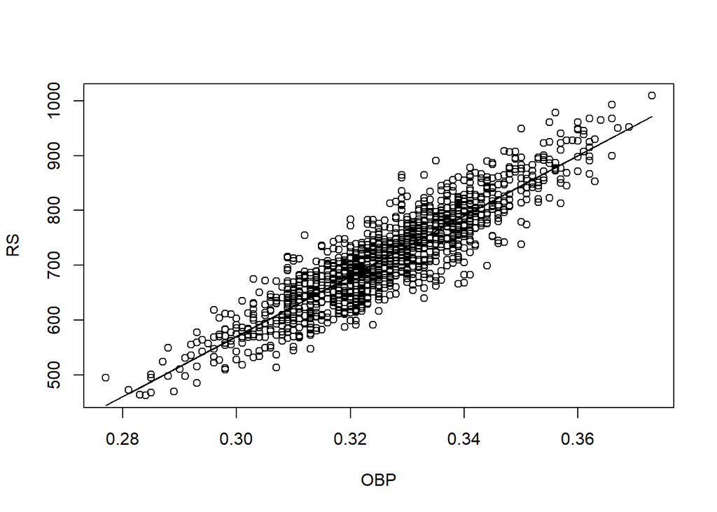

```r
plot(RS~OBP, baseball)
lines(baseball$OBP, predict(model))
```

The QQPlot shows that the data is not skewed as it follows the line very closely and it has a very light tail

```r
# fit linear regression model to predict runs scored using slugging percentage
model <- lm(RS ~ SLG, data = baseball)
# get coefficients
coefficients(model)
```

```
## (Intercept)         SLG
##    -289.368    2527.925
```

```r
# get r squared value
summary(model)$r.squared
```

```
## [1] 0.8440831
```

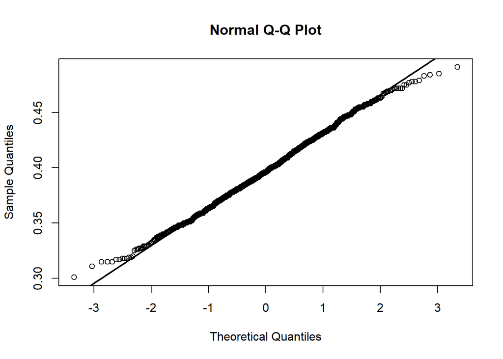

```r
# plot qq norm plot and qq line plot on data
qqnorm(baseball$SLG)
qqline(baseball$SLG, lwd=2)
```

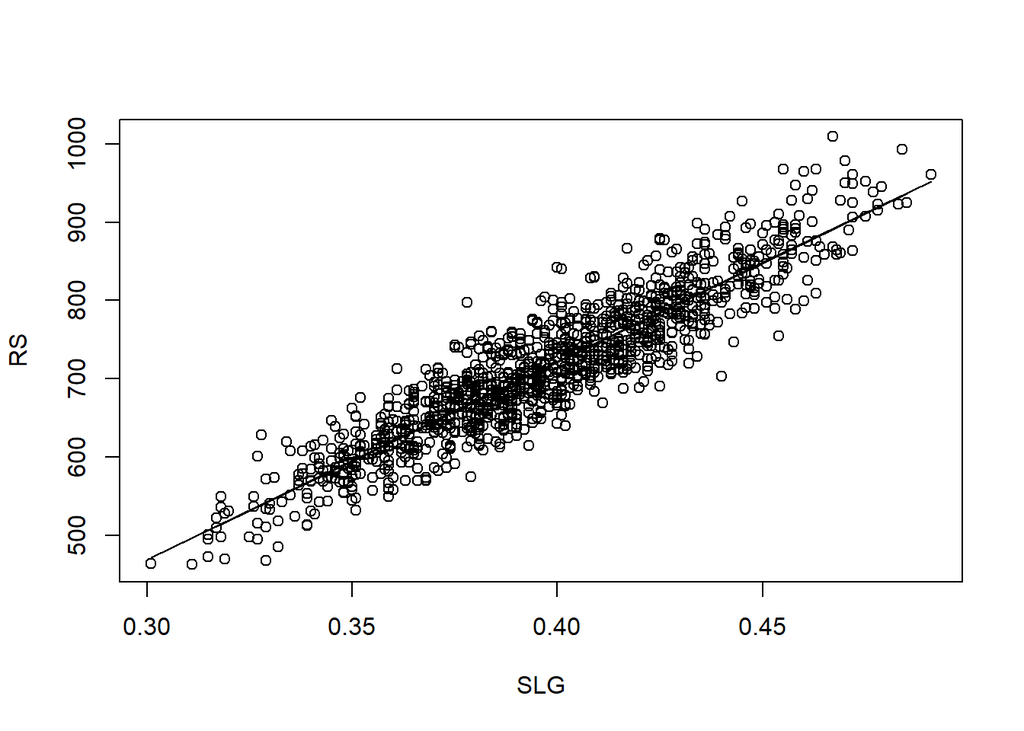

```r
plot(RS~SLG, baseball)
lines(baseball$SLG, predict(model))
```

The QQPlot shows that the data is not skewed as it follows the line very closely but has a light tail

```r
# fit multiple linear regression model on Batting average, slugging percentage and on base percentage
model <- lm(RS ~ BA + SLG + OBP, data = baseball)
# get coefficients, r squared and plot qq norm and qq line
coefficients(model)
```

```
## (Intercept)          BA         SLG         OBP
##   -806.0845   -134.9050   1533.8848   2900.9403
```

```r
summary(model)$r.squared
```

```
## [1] 0.9248834
```

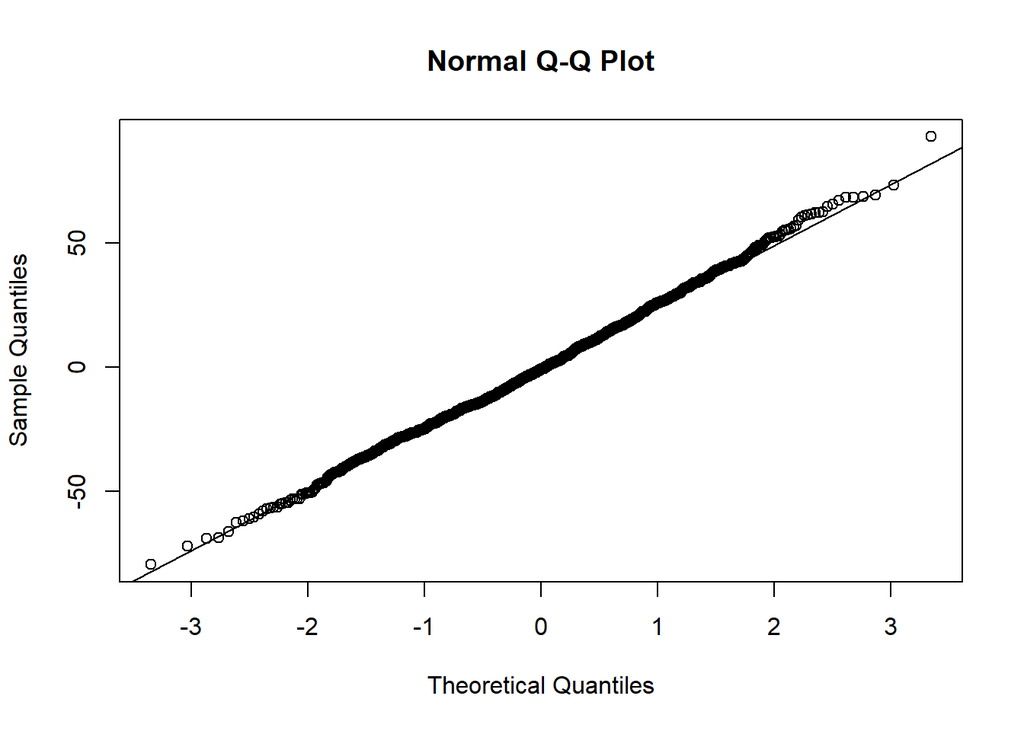

```r
qqnorm(resid(model))
qqline(resid(model))
```

The fitting result is consistent with that in part 2 only for SLG and OBP. The coefficient for BA is negative in the multi regression model while it is a very large positive number for the marginal model. The coefficient for SLG is olmost double the value in the marginal compared to the multiple regression model. The OBP coefficient is also almost double in value in the marginal compared to the multiple regression model. The R^2 of the model is very high at 0.92 indicating a very good fit. The QQplot also almost perfectly fits the line so there is no skewing in the data and resembles the QQplot of OBP and SLG, so it seems these two are better at prediction than BA.

```r
# fit multiple linear regression model on Batting average and slugging percentage
model <- lm(RS ~ BA + SLG, data = baseball)
coefficients(model)
```

```
## (Intercept)          BA         SLG
##   -551.0843   1904.6587   1943.7683
```

```r
# get coefficients, r squared and plot qq norm and qq line
summary(model)$r.squared
```

```
## [1] 0.871143
```

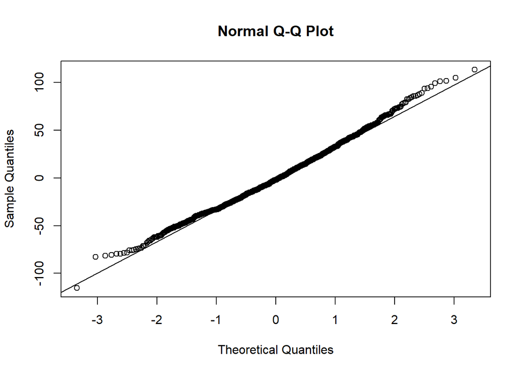

```r
qqnorm(resid(model))
qqline(resid(model))
```

```r
# fit multiple linear regression model on Batting average and slugging percentage
model <- lm(RS ~ OBP + SLG, data = baseball)
coefficients(model)
```

```
## (Intercept)         OBP         SLG
##   -811.6624   2830.7047   1517.5784
```

```r
# get coefficients, r squared and plot qq norm and qq line
summary(model)$r.squared
```

```
## [1] 0.9247974
```

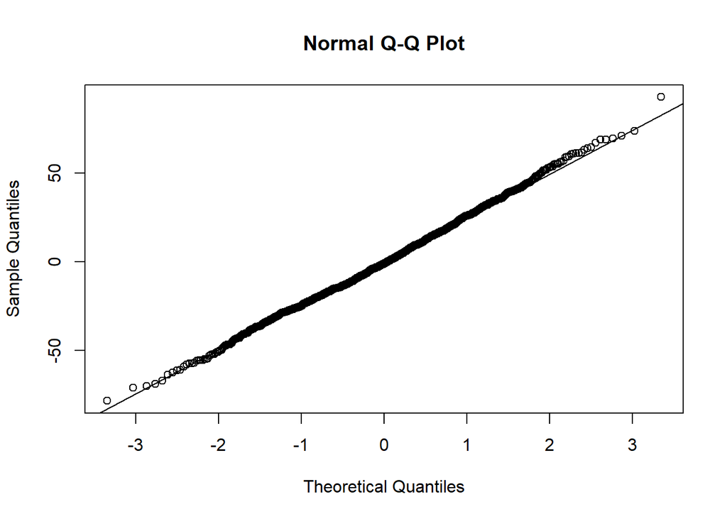

```r
qqnorm(resid(model))
qqline(resid(model))
```

Omitting OBP from the model resulted in the R^2 value to drop from ~0.92 t ~0.87. the QQ plot also shows there are light tails which are more prominant than that of the model which included OBP. The coefficients of BA and SLG are closer to their marginal coefficient values. Due to the higher R2 value and the fact that OBP and SLG are very important in calculating RS, I would choose the model which includes OBP as a covariate.

Lets see if we can predict the result for Oakland Athletics’ Wins for 2002.

```r
# subtract runs allowed from runs scored
baseball$RD <- baseball$RS - baseball$RA
# get data from prior to 2002
baseball2002 <- baseball[baseball$Year < 2002, ]
# Fit a linear model to predict wins based on RD
wfit <- lm(W~RD, data = baseball2002)
# fit a linear model to predict runs scored based on on base percentage
rsfit <- lm(RS~OBP + SLG, data = baseball2002)
# fit a linear model to predict runs allowed based on opponent on base percentage and opponent slugging percentage
rafit <- lm(RA ~ OOBP + OSLG, data = baseball2002)
# 2002 estimate for OBP, SLG, OOBP and OSLG for Oakland Athletics
OBP <- c(.349)
SLG <- c(.430)
OOBP <- c(.307)
OSLG <- c(.373)
# create data frame using these statistics and predict runs allowed using data frame
tofit <- data.frame(OBP, SLG, OOBP, OSLG)
rapred <- predict(rafit, tofit)
#predict runs scored using data frame
rspred <- predict(rsfit, tofit)
tofit$RA <- c(rapred)
tofit$RS <- c(rspred)
# prediction for RD based on RS and RA
tofit$RD <- c(rspred - rapred)
# predict wins, RA and RS
wpred <- predict(wfit, tofit)
wpred
```

```
##        1
## 103.1386
```

```r
rapred
```

```
##        1
## 621.9258
```

```r
rspred
```

```
##        1
## 832.3647
```

```r
# get actual results for wins, RA and RS
baseball[baseball$Team=="OAK" & baseball$Year==2002,]
```

```
##     Team League Year  RS  RA   W   OBP   SLG    BA Playoffs RankSeason
## 321  OAK     AL 2002 800 654 103 0.339 0.432 0.261        1          1
##     RankPlayoffs   G  OOBP  OSLG  RD
## 321            4 162 0.315 0.384 146
```

The prediction matches Oakland Athletics’ result for 2002 for wins, RA and RS were close.